# Lab 05 - Bipartite Graphs and Two-Mode Networks - SOLUTIONS

CRJ 507 Social Network Analysis

# Instructions

The purpose of this lab is to familiarize yourself with bipartite graphs and two-mode networks in *R*. Please review the [Bipartite Graphs/Two-Mode Networks](https://jacobtnyoung.github.io/sna-textbook/ch-10-bipartite-graphs.html) chapter of the [SNA Textbook](https://jacobtnyoung.github.io/sna-textbook/index.html) as well as the ipartite Graphs and Two-Mode Networks in R tutorial prior to beginning this lab.

## Part I: A Conspiracy Network

For this part of the lab, you will use data collected from [Paul Revere’s Ride](https://global.oup.com/ushe/product/paul-reveres-ride-9780195098310?cc=us&lang=en&), by David Fischer. In the book, Fischer documents Reveres connections through various affiliations in locations and how these influenced history. The Paul Revere conspiracy dataset concerns relationships between 254 people and their affiliations with seven different organizations in Boston. The dataset refers to Paul Revere, who was responsible for organizing a local militia of Boston’s revolutionary movement. The network is two-mode, with 254 actors and 7 organizations (“events”). We will refer to this network as the `PaulRevereNet`.

## Part II: A Kidnapping Network

For this part of the lab, you will use the Philippine Kidnappings Data which is a collection of relationships on the Abu Sayyaf Group (ASG), a violent non-state actor operating in the Southern Philippines. In particular, this data is related to the Salast movement that has been founded by Aburajak Janjalani, a native terrorist of the Southern Philippines in 1991. ASG is active in kidnapping and other kinds of terrorist attacks. The object is a two-mode network where actors are terrorist kidnappers and the terrorist events they have attended. We will refer to this as the `PhilKidnapNet` network.

For this part of the lab, use the `PhilKidnapNet` to repeat steps 1-8 in Part I.

# **Solutions**

## Setup

```r
# clear the workspace
rm( list = ls() )
```

## Part I

First, let’s read in the `PaulRevereNet` network. This is stored as an .rds document in the data folder on the [SNA Textbook](https://github.com/jacobtnyoung/sna-textbook/tree/main/data) site. We will use the `readRDS()` function, with the [file path](https://github.com/jacobtnyoung/sna-textbook/raw/main/data/data-paul-revere-net.rds), to load the file. Since we are calling a url, we need to use the `url()` function as well.

Finally, we need to make sure the `sna` and `network` packages are loaded, using `library()`, so that R recognizes the `PaulRevereNet` object as one of class `network`.

```r
# load the libraries we need
library( sna )
library( network )

# define the path location for the file
loc <- "https://github.com/jacobtnyoung/sna-textbook/raw/main/data/data-paul-revere-net.rds"
PaulRevereNet <- readRDS( url( loc ) )

# look at the network
PaulRevereNet
```

```
##  Network attributes:
##   vertices = 261
##   directed = FALSE
##   hyper = FALSE
##   loops = FALSE
##   multiple = FALSE
##   bipartite = 254
##   total edges= 334
##     missing edges= 0
##     non-missing edges= 334
##
##  Vertex attribute names:
##     names people.names place.names vertex.names
##
## No edge attributes
```

#### 1. Plot the network using the `gplot()` function.

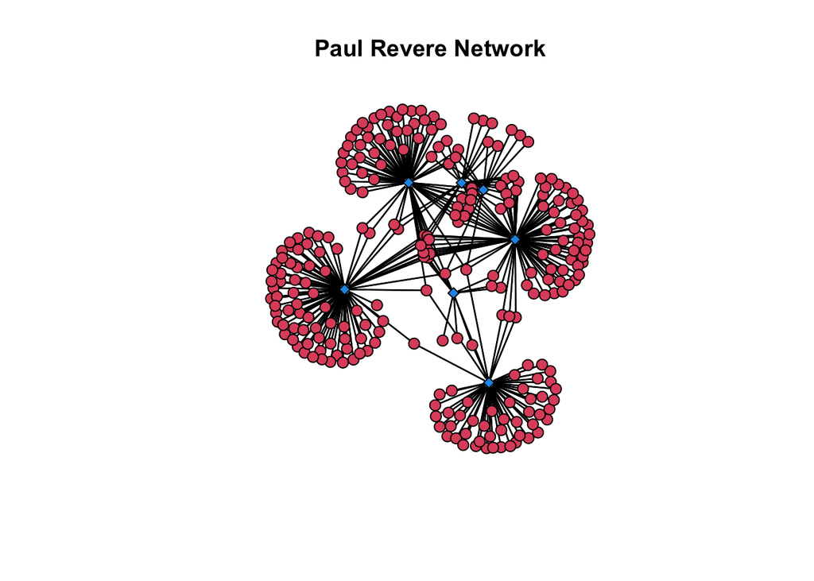

```r
# set the seed to reproduce the plot layout
set.seed( 507 )

# execute the plot
gplot(
  PaulRevereNet,             # our network to plot
  gmode = "twomode",         # indicate it is two modes
  usearrows = FALSE,         # turn off the arrowheads
  vertex.cex=2,              # size the nodes
  main="Paul Revere Network" # add a title
)
```

#### 2. Calculate the density of the network.

```r
# create a matrix from the network object
PaulRevereMat <- as.matrix( PaulRevereNet )

# identify the number of edges in the graph
L <- sum( PaulRevereMat )

# identify the number of actors in the example
N <- dim( PaulRevereMat )[1]

# identify the number of events in the example
M <- dim( PaulRevereMat )[2]

# calculate the density
density.PaulRevere <- L / ( N * M )

# check it out
density.PaulRevere
```

```
## [1] 0.1878515
```

#### 4. Calculate the degree centrality scores for each set of nodes.

```r
# raw scores for actors
actor.deg <- rowSums( PaulRevereMat )
actor.deg
```

```
##            Adams.John          Adams.Samuel              Allen.Dr
##                     2                     4                     1
##    Appleton.Nathaniel           Ash.Gilbert       Austin.Benjamin
##                     2                     1                     1
##         Austin.Samuel            Avery.John         Baldwin.Cyrus
##                     1                     2                     1
##          Ballard.John      Barber.Nathaniel        Barnard.Samuel
##                     1                     4                     1
##        Barrett.Samuel            Bass.Henry          Bell.William
##                     2                     4                     1
##        Blake.Increase             Boit.John         Bolter.Thomas
##                     1                     1                     1
##           Boyer.Peter       Boynton.Richard          Brackett.Jos
##                     1                     2                     1
##         Bradford.John         Bradlee.David        Bradlee.Josiah
##                     2                     1                     1
##     Bradlee.Nathaniel        Bradlee.Thomas           Bray.George
##                     1                     1                     1
##         Breck.William           Bewer.James        Brimmer.Herman
##                     1                     1                     1
##        Brimmer.Martin      Broomfield.Henry            Brown.Hugh
##                     1                     1                     1
##           Brown.Enoch            Brown.John         Bruce.Stephen
##                     1                     1                     1
##        Burbeck.Edward       Burbeck.William         Burt.Benjamin
##                     1                     1                     1
##       Burton.Benjamin     Cailleteau.Edward      Callendar.Elisha
##                     1                     1                     1
##     Campbell.Nicholas          Cazneau.Capt           Chadwell.Mr
##                     1                     1                     1
##        Champney.Caleb          Chase.Thomas       Cheever.Ezekiel
##                     1                     4                     2
##          Chipman.Seth        Chrysty.Thomas       Church.Benjamin
##                     1                     1                     2
##       Clarke.Benjamin      Cleverly.Stephen          Cochran.John
##                     4                     1                     2
##   Colesworthy.Gilbert       Collier.Gershom          Collins.Ezra
##                     1                     1                     1
##          Collson.Adam     Condy.JamesFoster         Cooper.Samuel
##                     2                     1                     1
```

[output cut: 115 more lines]

```
##                     1                     3                     1
##        Waldo.Benjamin         Warren.Joseph           Webb.Joseph
##                     1                     4                     1
##        Webster.Thomas          Welles.Henry        Wendell.Oliver
##                     1                     2                     2
##        Wheeler.Josiah          White.Samuel          Whitten.John
##                     1                     1                     1
##       Whitwell.Samuel      Whitwell.William     Williams.Jeremiah
##                     1                     1                     1
##     Williams.Jonathan       Williams.Thomas      Willis.Nathaniel
##                     1                     1                     1
##     Wingfield.William          Winslow.John         Winthrop.John
##                     1                     1                     2
##          Wyeth.Joshua          Young.Thomas
##                     1                     3
```

```r
# raw scores for events
event.deg <- colSums( PaulRevereMat )
event.deg
```

```
##  StAndrewsLodge       LoyalNine     NorthCaucus    LongRoomClub        TeaParty
##              55              11              69              13              83
## BostonCommittee   LondonEnemies
##              24              79
```

#### 5. Calculate the mean degree centrality scores and interpret the values.

```r
# mean degree for actors
mean.actor.deg <- L / N

# mean degree for events
mean.event.deg <- L / M

# an alternative is to just use the mean() function with the degree data
mean( actor.deg )
```

```
## [1] 1.314961
```

```r
mean( event.deg )
```

```
## [1] 47.71429
```

For the first set of nodes, the individuals who could attend events at locations, the mean degree is 1.3149606, meaning that on average, individuals attended 1.31 events.

For the second set of nodes, the locations where individuals could meet, the mean degree is 47.7142857, meaning that each location, on average, had 47.71 attendees.

#### 6. Calculate the standardized degree centrality scores for each set of nodes.

```r
# standardized score for actors
actor.deg / M
```

```
##            Adams.John          Adams.Samuel              Allen.Dr
##             0.2857143             0.5714286             0.1428571
##    Appleton.Nathaniel           Ash.Gilbert       Austin.Benjamin
##             0.2857143             0.1428571             0.1428571
##         Austin.Samuel            Avery.John         Baldwin.Cyrus
##             0.1428571             0.2857143             0.1428571
##          Ballard.John      Barber.Nathaniel        Barnard.Samuel
##             0.1428571             0.5714286             0.1428571
##        Barrett.Samuel            Bass.Henry          Bell.William
##             0.2857143             0.5714286             0.1428571
##        Blake.Increase             Boit.John         Bolter.Thomas
##             0.1428571             0.1428571             0.1428571
##           Boyer.Peter       Boynton.Richard          Brackett.Jos
##             0.1428571             0.2857143             0.1428571
##         Bradford.John         Bradlee.David        Bradlee.Josiah
##             0.2857143             0.1428571             0.1428571
##     Bradlee.Nathaniel        Bradlee.Thomas           Bray.George
##             0.1428571             0.1428571             0.1428571
##         Breck.William           Bewer.James        Brimmer.Herman
##             0.1428571             0.1428571             0.1428571
##        Brimmer.Martin      Broomfield.Henry            Brown.Hugh
##             0.1428571             0.1428571             0.1428571
##           Brown.Enoch            Brown.John         Bruce.Stephen
##             0.1428571             0.1428571             0.1428571
##        Burbeck.Edward       Burbeck.William         Burt.Benjamin
##             0.1428571             0.1428571             0.1428571
##       Burton.Benjamin     Cailleteau.Edward      Callendar.Elisha
##             0.1428571             0.1428571             0.1428571
##     Campbell.Nicholas          Cazneau.Capt           Chadwell.Mr
##             0.1428571             0.1428571             0.1428571
##        Champney.Caleb          Chase.Thomas       Cheever.Ezekiel
##             0.1428571             0.5714286             0.2857143
##          Chipman.Seth        Chrysty.Thomas       Church.Benjamin
##             0.1428571             0.1428571             0.2857143
##       Clarke.Benjamin      Cleverly.Stephen          Cochran.John
##             0.5714286             0.1428571             0.2857143
##   Colesworthy.Gilbert       Collier.Gershom          Collins.Ezra
##             0.1428571             0.1428571             0.1428571
##          Collson.Adam     Condy.JamesFoster         Cooper.Samuel
##             0.2857143             0.1428571             0.1428571
```

[output cut: 115 more lines]

```
##             0.1428571             0.4285714             0.1428571
##        Waldo.Benjamin         Warren.Joseph           Webb.Joseph
##             0.1428571             0.5714286             0.1428571
##        Webster.Thomas          Welles.Henry        Wendell.Oliver
##             0.1428571             0.2857143             0.2857143
##        Wheeler.Josiah          White.Samuel          Whitten.John
##             0.1428571             0.1428571             0.1428571
##       Whitwell.Samuel      Whitwell.William     Williams.Jeremiah
##             0.1428571             0.1428571             0.1428571
##     Williams.Jonathan       Williams.Thomas      Willis.Nathaniel
##             0.1428571             0.1428571             0.1428571
##     Wingfield.William          Winslow.John         Winthrop.John
##             0.1428571             0.1428571             0.2857143
##          Wyeth.Joshua          Young.Thomas
##             0.1428571             0.4285714
```

```r
# standardized score for events
event.deg / N
```

```
##  StAndrewsLodge       LoyalNine     NorthCaucus    LongRoomClub        TeaParty
##      0.21653543      0.04330709      0.27165354      0.05118110      0.32677165
## BostonCommittee   LondonEnemies
##      0.09448819      0.31102362
```

#### 7. Calculate the mean standardized degree centrality score.

```r
# mean standardized score for actors
mean( actor.deg / M )
```

```
## [1] 0.1878515
```

```r
# mean standardized score for events
mean( event.deg / N )
```

```
## [1] 0.1878515
```

Notice that these are the same because we adjusted for the different sizes of *M* and *N* in the network.

#### 8. Plot the network using the standardized degree centrality scores.

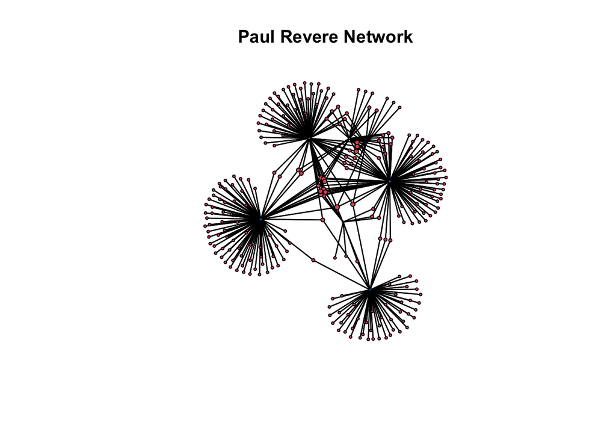

```r
# define the standardized scores for actors
actor.size <- actor.deg / M

# define the standardized scores for events
event.size <- event.deg / N

# combine these to use in the plot
v.size <- c( actor.size, event.size )

# set the seed to reproduce the plot layout
set.seed( 507 )

# execute the plot
gplot(
  PaulRevereNet,              # our network to plot
  gmode = "twomode",          # indicate it is two modes
  usearrows = FALSE,          # turn off the arrowheads
  main="Paul Revere Network", # add a title
  vertex.cex = v.size + 0.5   # set the size (add 0.5 so it is not too small)
)
```

#### 9. Using the vertex attribute `people.names`, discuss which individual is most central in the network.

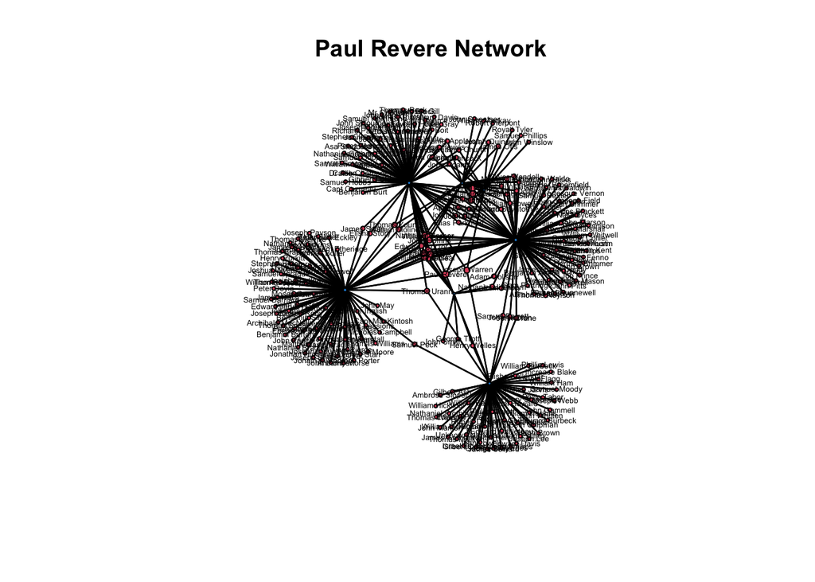

```r
# set the seed to reproduce the plot layout
set.seed( 507 )

# execute the plot
gplot(
  PaulRevereNet,
  gmode = "twomode",
  usearrows = FALSE,
  main="Paul Revere Network",
  vertex.cex = v.size + 0.5,
  label = PaulRevereNet %v% "people.names",    # add the individual names
  label.cex = 0.4,                             # change the label size
  label.pos = 5                                # set the label position
)
```

This is hard to see! One way around this is to just show labels for the those nodes that have degree centrality scores at or above the mean. Let’s see how we can do this.

First, identify who is the most central person. We can do this using the `sort()` function.

```r
sort( actor.deg / M )
```

```
##              Allen.Dr           Ash.Gilbert       Austin.Benjamin
##             0.1428571             0.1428571             0.1428571
##         Austin.Samuel         Baldwin.Cyrus          Ballard.John
##             0.1428571             0.1428571             0.1428571
##        Barnard.Samuel          Bell.William        Blake.Increase
##             0.1428571             0.1428571             0.1428571
##             Boit.John         Bolter.Thomas           Boyer.Peter
##             0.1428571             0.1428571             0.1428571
##          Brackett.Jos         Bradlee.David        Bradlee.Josiah
##             0.1428571             0.1428571             0.1428571
##     Bradlee.Nathaniel        Bradlee.Thomas           Bray.George
##             0.1428571             0.1428571             0.1428571
##         Breck.William           Bewer.James        Brimmer.Herman
##             0.1428571             0.1428571             0.1428571
##        Brimmer.Martin      Broomfield.Henry            Brown.Hugh
##             0.1428571             0.1428571             0.1428571
##           Brown.Enoch            Brown.John         Bruce.Stephen
##             0.1428571             0.1428571             0.1428571
##        Burbeck.Edward       Burbeck.William         Burt.Benjamin
##             0.1428571             0.1428571             0.1428571
##       Burton.Benjamin     Cailleteau.Edward      Callendar.Elisha
##             0.1428571             0.1428571             0.1428571
##     Campbell.Nicholas          Cazneau.Capt           Chadwell.Mr
##             0.1428571             0.1428571             0.1428571
##        Champney.Caleb          Chipman.Seth        Chrysty.Thomas
##             0.1428571             0.1428571             0.1428571
##      Cleverly.Stephen   Colesworthy.Gilbert       Collier.Gershom
##             0.1428571             0.1428571             0.1428571
##          Collins.Ezra     Condy.JamesFoster         Cooper.Samuel
##             0.1428571             0.1428571             0.1428571
##         Crafts.Thomas          Davis.Edward          Davis.Robert
##             0.1428571             0.1428571             0.1428571
##         Davis.William          Dawes.Thomas        Dennie.William
##             0.1428571             0.1428571             0.1428571
##         Dexter.Samuel           Doyle.Peter          Eaton.Joseph
##             0.1428571             0.1428571             0.1428571
##         Eayres.Joseph        Eckley.Unknown         Edes.Benjamin
##             0.1428571             0.1428571             0.1428571
##          Emmes.Samuel     Etheridge.William          Fenno.Samuel
##             0.1428571             0.1428571             0.1428571
```

[output cut: 115 more lines]

```
##             0.2857143             0.2857143             0.2857143
##          Welles.Henry        Wendell.Oliver         Winthrop.John
##             0.2857143             0.2857143             0.2857143
##      Molineux.William        Proctor.Edward          Urann.Thomas
##             0.4285714             0.4285714             0.4285714
##          Young.Thomas          Adams.Samuel      Barber.Nathaniel
##             0.4285714             0.5714286             0.5714286
##            Bass.Henry          Chase.Thomas       Clarke.Benjamin
##             0.5714286             0.5714286             0.5714286
##        Cooper.William           Davis.Caleb     Greenleaf.William
##             0.5714286             0.5714286             0.5714286
##          Hancock.John          Hoffins.John         Hopkins.Caleb
##             0.5714286             0.5714286             0.5714286
##         Warren.Joseph           Revere.Paul
##             0.5714286             0.7142857
```

We see it is Paul Revere!

Now, we want to change the names to only show Paul Revere’s name.

```r
# create a vector of names to change
actor.adj.names <- PaulRevereNet %v% "people.names"

# if the name is not Paul Revere, make it NA
actor.adj.names[ actor.adj.names != "Paul Revere" ] <- NA
```

Now that we have adjusted the names, we can plot it.

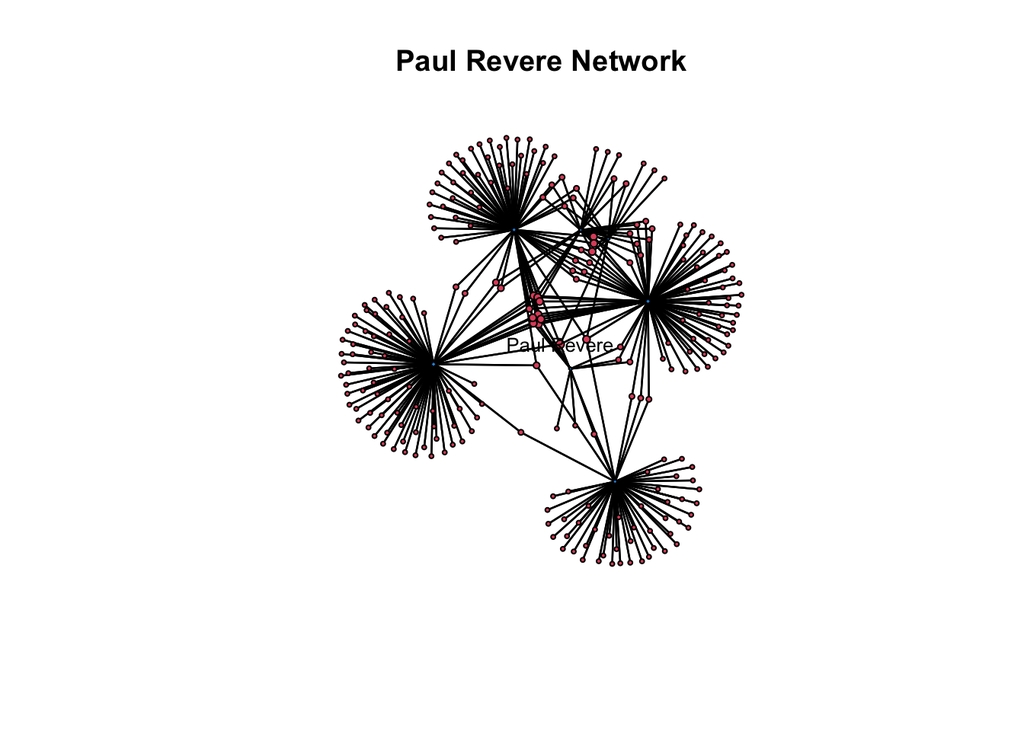

```r
# set the seed to reproduce the plot layout
set.seed( 507 )

# execute the plot
gplot(
  PaulRevereNet,
  gmode = "twomode",
  usearrows = FALSE,
  main="Paul Revere Network",
  vertex.cex = v.size + 0.5,
  label = actor.adj.names,    # here we use the new names
  label.cex = 0.8,            # change the label size
  label.pos = 5
)
```

#### 10. Using the vertex attribute `place.names`, discuss which location is most central in the network.

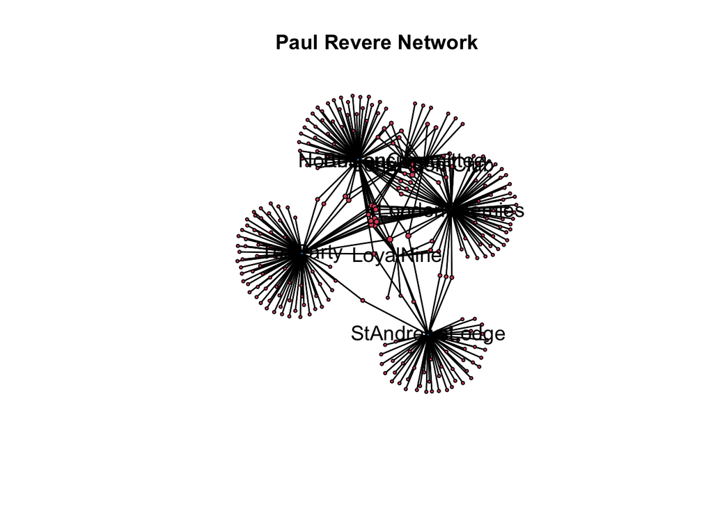

```r
# set the seed to reproduce the plot layout
set.seed( 507 )

# execute the plot
gplot(
  PaulRevereNet,
  gmode = "twomode",
  usearrows = FALSE,
  main="Paul Revere Network",
  vertex.cex = v.size + 0.5,
  label = PaulRevereNet %v% "place.names",  # use the place names
  label.cex = 1.2,
  label.pos = 5
)
```

Again, this is a bit tricky to see from the plot. *But*, we can examine the degree centrality scores as we did above with the `sort()` function.

```r
# sort the degree centrality scores in descending order
sort( event.deg / N )
```

```
##       LoyalNine    LongRoomClub BostonCommittee  StAndrewsLodge     NorthCaucus
##      0.04330709      0.05118110      0.09448819      0.21653543      0.27165354
##   LondonEnemies        TeaParty
##      0.31102362      0.32677165
```

We see it is the “TeaParty” location (although the “LondonEnemies” location is very close in size). We can see this a bit better in our plot by adjusting the color of the edges **and** expanding the size of the labels using the `rescale()` function.

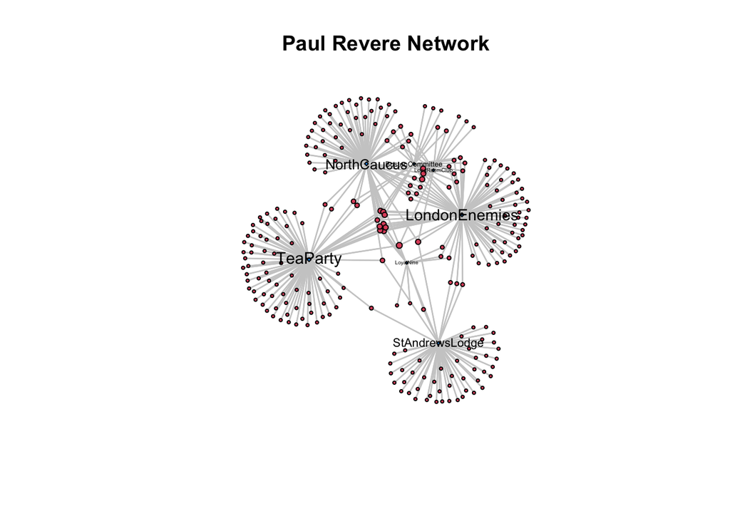

```r
# create the function
rescale <- function( nchar, low, high ){
  min_d <- min( nchar )
  max_d <- max( nchar )
  rscl  <- ( ( high - low )*( nchar - min_d ) ) / ( max_d - min_d ) + low
  rscl
}

# set the seed to reproduce the plot layout
set.seed( 507 )

# execute the plot
gplot(
  PaulRevereNet,
  gmode = "twomode",
  usearrows = FALSE,
  main="Paul Revere Network",
  vertex.cex = v.size + 0.5,
  label = PaulRevereNet %v% "place.names",
  label.cex = rescale( v.size, 0.3, 1.8 ), # pass the rescale function to the label.cex argument
  label.pos = 5,
  edge.col = "grey80"                      # change the color of the edges
)
```

## Part II

First, let’s read in the `PhilKidnapNet` network. This is stored as an .rds document in the data folder on the [SNA Textbook](https://github.com/jacobtnyoung/sna-textbook/tree/main/data) site. We will use the `readRDS()` function, with the [file path](https://github.com/jacobtnyoung/sna-textbook/raw/main/data/data-philippine-kidnappings-net.rds), to load the file. Since we are calling a url, we need to use the `url()` function as well.

Finally, we need to make sure the `sna` and `network` packages are loaded, using `library()`, so that R recognizes the `PhilKidnapNet` object as one of class `network`.

```r
# clear the workspace so we don't use any duplicate names
rm( list = ls() )

# define the path location for the file
loc <- "https://github.com/jacobtnyoung/sna-textbook/raw/main/data/data-philippine-kidnappings-net.rds"
PhilKidnapNet <- readRDS( url( loc ) )

# look at the network
PhilKidnapNet
```

```
##  Network attributes:
##   vertices = 351
##   directed = FALSE
##   hyper = FALSE
##   loops = FALSE
##   multiple = FALSE
##   bipartite = 246
##   total edges= 402
##     missing edges= 0
##     non-missing edges= 402
##
##  Vertex attribute names:
##     vertex.names
##
## No edge attributes
```

#### 1. Plot the network using the `gplot()` function.

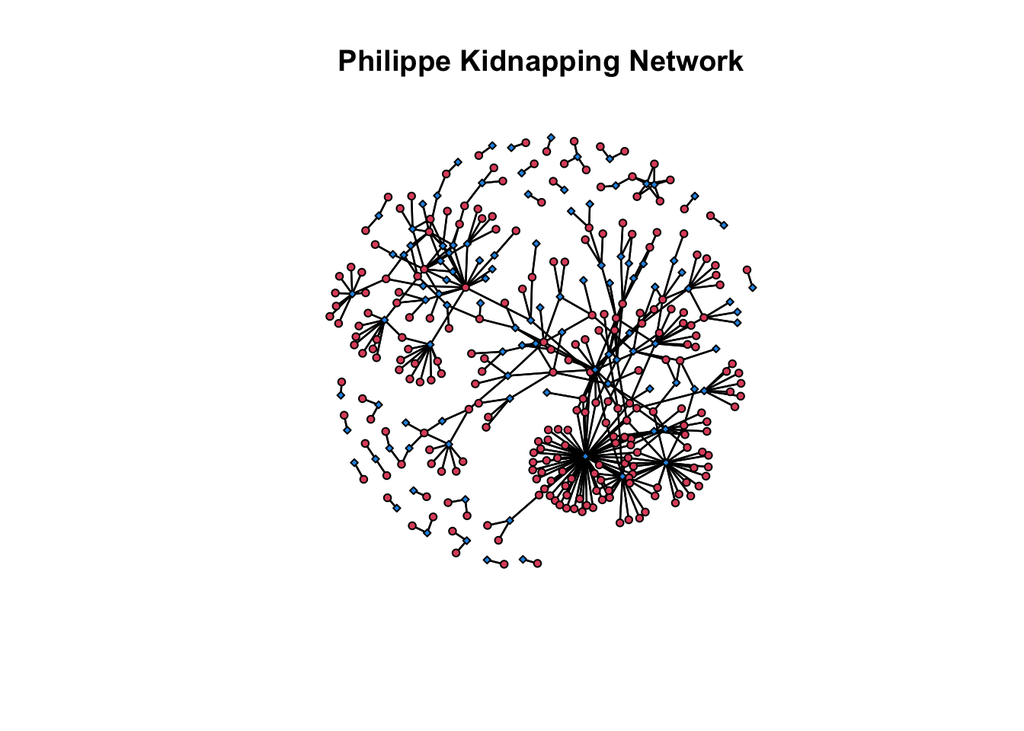

```r
# set the seed to reproduce the plot layout
set.seed( 507 )

# execute the plot
gplot(
  PhilKidnapNet,
  gmode = "twomode",
  usearrows = FALSE,
  vertex.cex = 1.2,
  main="Philippe Kidnapping Network"
)
```

#### 2. Calculate the density of the network.

```r
# create a matrix from the network object
PhilKidnapMat <- as.matrix( PhilKidnapNet )

# identify the number of edges in the graph
L <- sum( PhilKidnapMat )

# identify the number of actors in the example
N <- dim( PhilKidnapMat )[1]

# identify the number of events in the example
M <- dim( PhilKidnapMat )[2]

# calculate the density
density.PhilKidnap <- L / ( N * M )

# check it out
density.PhilKidnap
```

```
## [1] 0.0155633
```

#### 4. Calculate the degree centrality scores for each set of nodes.

```r
# raw scores for actors
actor.deg <- rowSums( PhilKidnapMat )
actor.deg
```

```
##   N1   N2   N3   N4   N5   N6   N7   N8   N9  N10  N11  N12  N13  N14  N15  N16
##    5    2    9    3    4    4    2    1    4    7    1    1    3    1    1    1
##  N17  N18  N19  N20  N21  N22  N23  N24  N25  N26  N27  N28  N29  N30  N31  N32
##    1    2    6    1    1    1    3    1    1    1    2    1    3    1    1    3
##  N33  N34  N35  N36  N37  N38  N39  N40  N41  N42  N43  N44  N45  N46  N47  N48
##    1    1    1    3    6    2    1    1    4    2    3    2    1    1    1    3
##  N49  N50  N51  N52  N53  N54  N55  N56  N57  N58  N59  N60  N61  N62  N63  N64
##    1    2    1    1    1    1    2    1    1    1    4    1    1    1    1    1
##  N65  N66  N67  N68  N69  N70  N71  N72  N73  N74  N75  N76  N77  N78  N79  N80
##    1    4    1    2    1    1    1    2    2    1    2    2    2    2    2    2
##  N81  N82  N83  N84  N85  N86  N87  N88  N89  N90  N91  N92  N93  N94  N95  N96
##    1    2    2    2    3    1    1    1    1    1    9    4    1    2    1    1
##  N97  N98  N99 N100 N101 N102 N103 N104 N105 N106 N107 N108 N109 N110 N111 N112
##    2    1    2    1    1    1   16    1    1    1    1    1    1    1    1    1
## N113 N114 N115 N116 N117 N118 N119 N120 N121 N122 N123 N124 N125 N126 N127 N128
##    5    1    1    1    2    1    1    1    1    1    3    1    2    1   11    2
## N129 N130 N131 N132 N133 N134 N135 N136 N137 N138 N139 N140 N141 N142 N143 N144
##    1    3    1    1    1    1    1    1    1    1    1    1    3    1    1    1
## N145 N146 N147 N148 N149 N150 N151 N152 N153 N154 N155 N156 N157 N158 N159 N160
##    3    1    1    1    1    1    1    1    1    1    1    3    1    1    1    1
## N161 N162 N163 N164 N165 N166 N167 N168 N169 N170 N171 N172 N173 N174 N175 N176
##    1    1    1    1    1    1    1    1    1    1    1    1    1    2    1    1
## N177 N178 N179 N180 N181 N182 N183 N184 N185 N186 N187 N188 N189 N190 N191 N192
##    1    1    1    2    1    1    1    1    1    1    2    1    1    1    1    1
## N193 N194 N195 N196 N197 N198 N199 N200 N201 N202 N203 N204 N205 N206 N207 N208
##    1    1    1    1    1    1    3    2    2    2    2    1    1    1    1    1
## N209 N210 N211 N212 N213 N214 N215 N216 N217 N218 N219 N220 N221 N222 N223 N224
##    1    1    1    3    1    1    1    1    1    1    1    1    1    1    1    1
## N225 N226 N227 N228 N229 N230 N231 N232 N233 N234 N235 N236 N237 N238 N239 N240
##    1    1    1    1    2    2    1    1    1    1    1    1    1    1    1    1
## N241 N242 N243 N244 N245 N246
##    1    1    1    3    1    1
```

```r
# raw scores for events
event.deg <- colSums( PhilKidnapMat )
event.deg
```

```
##   E1   E2   E3   E4   E5   E6   E7   E8   E9  E10  E11  E12  E13  E14  E15  E16
##    2    1    7    3    1    5    2    6    3    4    1    3    1    1    2    2
##  E17  E18  E19  E20  E21  E22  E23  E24  E25  E26  E27  E28  E29  E30  E31  E32
##    3    2    4    1    2    1    3    1    2    2   17    2    4   23    3   15
##  E33  E34  E35  E36  E37  E38  E39  E40  E41  E42  E43  E44  E45  E46  E47  E48
##    2    6   58    2    1    1   11    1    6    5    1    2    1    3    1    1
##  E49  E50  E51  E52  E53  E54  E55  E56  E57  E58  E59  E60  E61  E62  E63  E64
##    1    1    2    2    3    6    2    2    3    1    1    1    2    1    3    2
##  E65  E66  E67  E68  E69  E70  E71  E72  E73  E74  E75  E76  E77  E78  E79  E80
##   12    2    8    1    3    1    5    5    9    8    4    1    3    4    4    1
##  E81  E82  E83  E84  E85  E86  E87  E88  E89  E90  E91  E92  E93  E94  E95  E96
##   11    1    3   10    4    1    1    1    1    1    2    1    1    2    1    2
##  E97  E98  E99 E100 E101 E102 E103 E104 E105
##    2    5    2    5    1    2    2    4    1
```

#### 5. Calculate the mean degree centrality scores and interpret the values.

```r
# mean degree for actors
mean.actor.deg <- L / N

# mean degree for events
mean.event.deg <- L / M

# an alternative is to just use the mean() function with the degree data
mean( actor.deg )
```

```
## [1] 1.634146
```

```r
mean( event.deg )
```

```
## [1] 3.828571
```

For the first set of nodes, the individuals who could attend events at locations, the mean degree is 1.6341463, meaning that on average, individuals attended 1.63 events.

For the second set of nodes, the locations where individuals could meet, the mean degree is 3.8285714, meaning that each location, on average, had 3.83 attendees.

#### 6. Calculate the standardized degree centrality scores for each set of nodes.

```r
# standardized score for actors
actor.deg / M
```

```
##         N1         N2         N3         N4         N5         N6         N7
## 0.04761905 0.01904762 0.08571429 0.02857143 0.03809524 0.03809524 0.01904762
##         N8         N9        N10        N11        N12        N13        N14
## 0.00952381 0.03809524 0.06666667 0.00952381 0.00952381 0.02857143 0.00952381
##        N15        N16        N17        N18        N19        N20        N21
## 0.00952381 0.00952381 0.00952381 0.01904762 0.05714286 0.00952381 0.00952381
##        N22        N23        N24        N25        N26        N27        N28
## 0.00952381 0.02857143 0.00952381 0.00952381 0.00952381 0.01904762 0.00952381
##        N29        N30        N31        N32        N33        N34        N35
## 0.02857143 0.00952381 0.00952381 0.02857143 0.00952381 0.00952381 0.00952381
##        N36        N37        N38        N39        N40        N41        N42
## 0.02857143 0.05714286 0.01904762 0.00952381 0.00952381 0.03809524 0.01904762
##        N43        N44        N45        N46        N47        N48        N49
## 0.02857143 0.01904762 0.00952381 0.00952381 0.00952381 0.02857143 0.00952381
##        N50        N51        N52        N53        N54        N55        N56
## 0.01904762 0.00952381 0.00952381 0.00952381 0.00952381 0.01904762 0.00952381
##        N57        N58        N59        N60        N61        N62        N63
## 0.00952381 0.00952381 0.03809524 0.00952381 0.00952381 0.00952381 0.00952381
##        N64        N65        N66        N67        N68        N69        N70
## 0.00952381 0.00952381 0.03809524 0.00952381 0.01904762 0.00952381 0.00952381
##        N71        N72        N73        N74        N75        N76        N77
## 0.00952381 0.01904762 0.01904762 0.00952381 0.01904762 0.01904762 0.01904762
##        N78        N79        N80        N81        N82        N83        N84
## 0.01904762 0.01904762 0.01904762 0.00952381 0.01904762 0.01904762 0.01904762
##        N85        N86        N87        N88        N89        N90        N91
## 0.02857143 0.00952381 0.00952381 0.00952381 0.00952381 0.00952381 0.08571429
##        N92        N93        N94        N95        N96        N97        N98
## 0.03809524 0.00952381 0.01904762 0.00952381 0.00952381 0.01904762 0.00952381
##        N99       N100       N101       N102       N103       N104       N105
## 0.01904762 0.00952381 0.00952381 0.00952381 0.15238095 0.00952381 0.00952381
##       N106       N107       N108       N109       N110       N111       N112
## 0.00952381 0.00952381 0.00952381 0.00952381 0.00952381 0.00952381 0.00952381
##       N113       N114       N115       N116       N117       N118       N119
## 0.04761905 0.00952381 0.00952381 0.00952381 0.01904762 0.00952381 0.00952381
##       N120       N121       N122       N123       N124       N125       N126
## 0.00952381 0.00952381 0.00952381 0.02857143 0.00952381 0.01904762 0.00952381
##       N127       N128       N129       N130       N131       N132       N133
## 0.10476190 0.01904762 0.00952381 0.02857143 0.00952381 0.00952381 0.00952381
##       N134       N135       N136       N137       N138       N139       N140
## 0.00952381 0.00952381 0.00952381 0.00952381 0.00952381 0.00952381 0.00952381
```

[output cut: 17 more lines]

```
## 0.00952381 0.00952381 0.02857143 0.01904762 0.01904762 0.01904762 0.01904762
##       N204       N205       N206       N207       N208       N209       N210
## 0.00952381 0.00952381 0.00952381 0.00952381 0.00952381 0.00952381 0.00952381
##       N211       N212       N213       N214       N215       N216       N217
## 0.00952381 0.02857143 0.00952381 0.00952381 0.00952381 0.00952381 0.00952381
##       N218       N219       N220       N221       N222       N223       N224
## 0.00952381 0.00952381 0.00952381 0.00952381 0.00952381 0.00952381 0.00952381
##       N225       N226       N227       N228       N229       N230       N231
## 0.00952381 0.00952381 0.00952381 0.00952381 0.01904762 0.01904762 0.00952381
##       N232       N233       N234       N235       N236       N237       N238
## 0.00952381 0.00952381 0.00952381 0.00952381 0.00952381 0.00952381 0.00952381
##       N239       N240       N241       N242       N243       N244       N245
## 0.00952381 0.00952381 0.00952381 0.00952381 0.00952381 0.02857143 0.00952381
##       N246
## 0.00952381
```

```r
# standardized score for events
event.deg / N
```

```
##          E1          E2          E3          E4          E5          E6
## 0.008130081 0.004065041 0.028455285 0.012195122 0.004065041 0.020325203
##          E7          E8          E9         E10         E11         E12
## 0.008130081 0.024390244 0.012195122 0.016260163 0.004065041 0.012195122
##         E13         E14         E15         E16         E17         E18
## 0.004065041 0.004065041 0.008130081 0.008130081 0.012195122 0.008130081
##         E19         E20         E21         E22         E23         E24
## 0.016260163 0.004065041 0.008130081 0.004065041 0.012195122 0.004065041
##         E25         E26         E27         E28         E29         E30
## 0.008130081 0.008130081 0.069105691 0.008130081 0.016260163 0.093495935
##         E31         E32         E33         E34         E35         E36
## 0.012195122 0.060975610 0.008130081 0.024390244 0.235772358 0.008130081
##         E37         E38         E39         E40         E41         E42
## 0.004065041 0.004065041 0.044715447 0.004065041 0.024390244 0.020325203
##         E43         E44         E45         E46         E47         E48
## 0.004065041 0.008130081 0.004065041 0.012195122 0.004065041 0.004065041
##         E49         E50         E51         E52         E53         E54
## 0.004065041 0.004065041 0.008130081 0.008130081 0.012195122 0.024390244
##         E55         E56         E57         E58         E59         E60
## 0.008130081 0.008130081 0.012195122 0.004065041 0.004065041 0.004065041
##         E61         E62         E63         E64         E65         E66
## 0.008130081 0.004065041 0.012195122 0.008130081 0.048780488 0.008130081
##         E67         E68         E69         E70         E71         E72
## 0.032520325 0.004065041 0.012195122 0.004065041 0.020325203 0.020325203
##         E73         E74         E75         E76         E77         E78
## 0.036585366 0.032520325 0.016260163 0.004065041 0.012195122 0.016260163
##         E79         E80         E81         E82         E83         E84
## 0.016260163 0.004065041 0.044715447 0.004065041 0.012195122 0.040650407
##         E85         E86         E87         E88         E89         E90
## 0.016260163 0.004065041 0.004065041 0.004065041 0.004065041 0.004065041
##         E91         E92         E93         E94         E95         E96
## 0.008130081 0.004065041 0.004065041 0.008130081 0.004065041 0.008130081
##         E97         E98         E99        E100        E101        E102
## 0.008130081 0.020325203 0.008130081 0.020325203 0.004065041 0.008130081
##        E103        E104        E105
## 0.008130081 0.016260163 0.004065041
```

#### 7. Calculate the mean standardized degree centrality score.

```r
# mean standardized score for actors
mean( actor.deg / M )
```

```
## [1] 0.0155633
```

```r
# mean standardized score for events
mean( event.deg / N )
```

```
## [1] 0.0155633
```

Notice that these are the same because we adjusted for the different sizes of *M* and *N* in the network.

#### 8. Plot the network using the standardized degree centrality scores.

First, let’s reload the `rescale()` function to help with the plot sizes.

```r
# create the function
rescale <- function( nchar, low, high ){
  min_d <- min( nchar )
  max_d <- max( nchar )
  rscl  <- ( ( high - low )*( nchar - min_d ) ) / ( max_d - min_d ) + low
  rscl
}
```

Now, we can create the vector of sizes and make the plot.

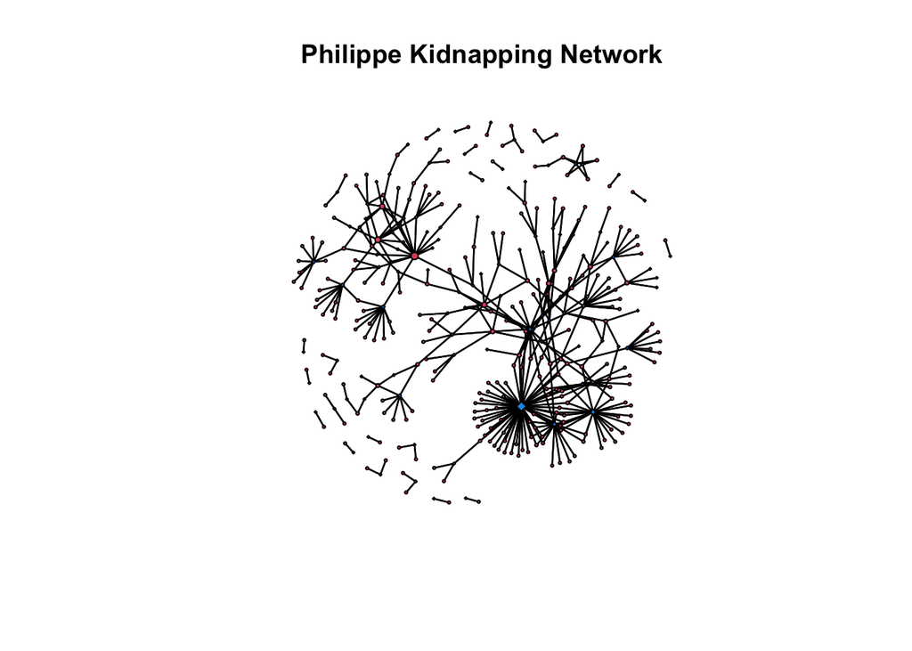

```r
# define the standardized scores for actors
actor.size <- actor.deg / M

# define the standardized scores for events
event.size <- event.deg / N

# combine these to use in the plot
v.size <- c( actor.size, event.size )

# set the seed to reproduce the plot layout
set.seed( 507 )

# execute the plot
gplot(
  PhilKidnapNet,
  gmode = "twomode",
  usearrows = FALSE,
  main="Philippe Kidnapping Network",
  vertex.cex = rescale( v.size, 0.5, 1.8 )
)
```

#### 9 & 10. Using the vertex attribute `vertex.names`, discuss which individual and which event are the most central in the network.

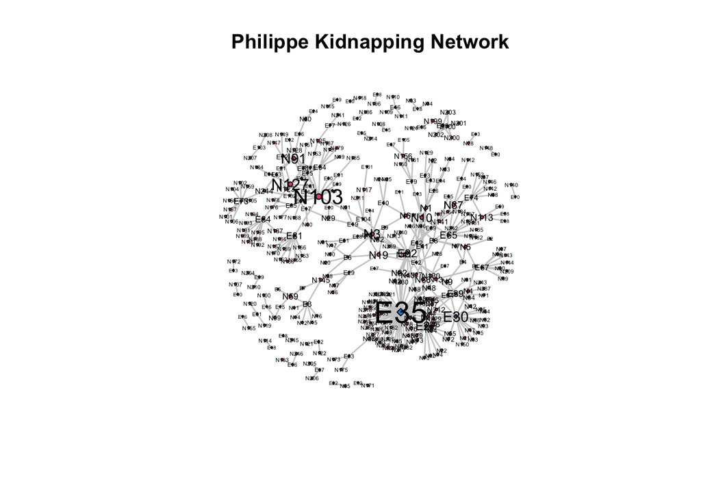

```r
# set the seed to reproduce the plot layout
set.seed( 507 )

# execute the plot
gplot(
  PhilKidnapNet,
  gmode = "twomode",
  usearrows = FALSE,
  main="Philippe Kidnapping Network",
  vertex.cex = rescale( v.size, 0.5, 1.8 ),
  label = PhilKidnapNet %v% "vertex.names", # add the individual names
  label.cex = rescale( v.size, 0.3, 1.8 ),  # pass the rescale function to the label.cex argument
  label.pos = 5,                            # set the label position
  edge.col = "grey80"                       # change the color of the edges
)
```

From the plot, we can see that 103 is the most central actor indicating that this person attended the most meetings. And, we see that 35 is the most central event meaning that this meeting had the most attendees.

##### *Please* report any needed corrections to the [Issues](https://github.com/Watts-College/crj-507-template/issues) page. Thanks!